# Introduction to ggplot2

Derek Sollberger

August 27, 2017

# Grammar of Graphics

```r
library("tidyverse")
library("ggplot2")
library("mosaicData")
```

## One-dimensional, continuous data

Let’s start with a simple data set where a budding scientist took $n = 30$ dimes and weighed them.

```r
data(Dimes)
head(Dimes)
```

```
##    mass year
## 1 2.259 2004
## 2 2.247 2004
## 3 2.254 1987
## 4 2.298 1988
## 5 2.287 1971
## 6 2.254 2007
```

We can see that we have data about the mass and the year for each dime. Treating the years as a *discrete variable*, it may be easist to visualize the years with a `dotplot`.

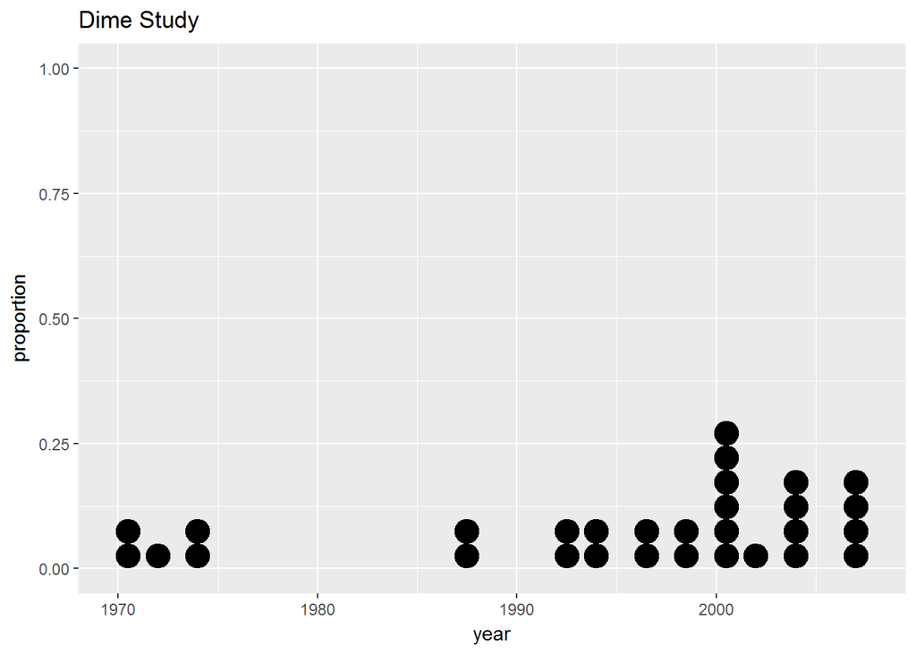

```r
ggplot(Dimes, aes(x = year)) +
  geom_dotplot() +
  ggtitle("Dime Study") +
  ylab("proportion")
```

Treating the masses as a *continuous variable*, it may be best to visualize the masses with a `histogram`.

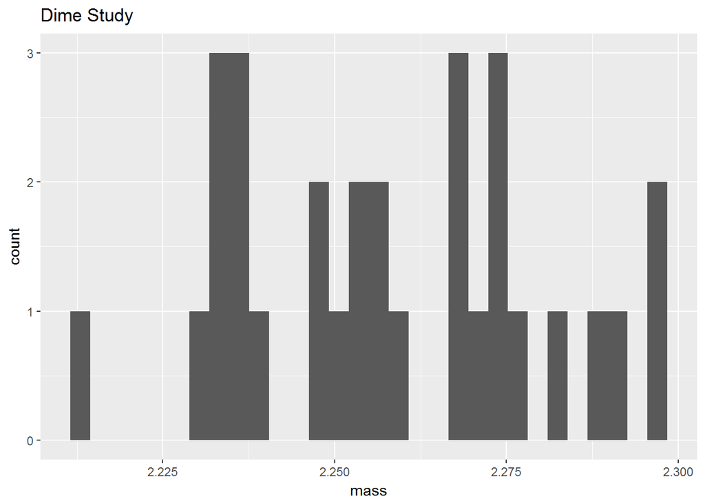

```r
ggplot(Dimes, aes(x = mass)) +
  geom_histogram() +
  ggtitle("Dime Study")
```

We can also change the `binwidth`.

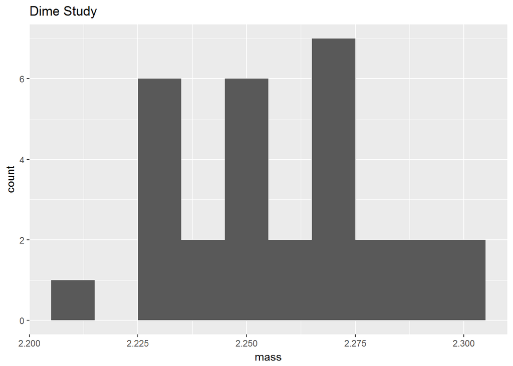

```r
ggplot(Dimes, aes(x = mass)) +
  geom_histogram(binwidth = 0.01) +
  ggtitle("Dime Study")
```

Let us now look at a more interesting data set. The `SAT` data features state-by-state average results from SAT tests from 1995.

```r
data(SAT)
head(SAT)
```

```
##        state expend ratio salary frac verbal math  sat
## 1    Alabama  4.405  17.2 31.144    8    491  538 1029
## 2     Alaska  8.963  17.6 47.951   47    445  489  934
## 3    Arizona  4.778  19.3 32.175   27    448  496  944
## 4   Arkansas  4.459  17.1 28.934    6    482  523 1005
## 5 California  4.992  24.0 41.078   45    417  485  902
## 6   Colorado  5.443  18.4 34.571   29    462  518  980
```

A *continuous* approximation to the distribution of the data is called a **kernel density estimate**.

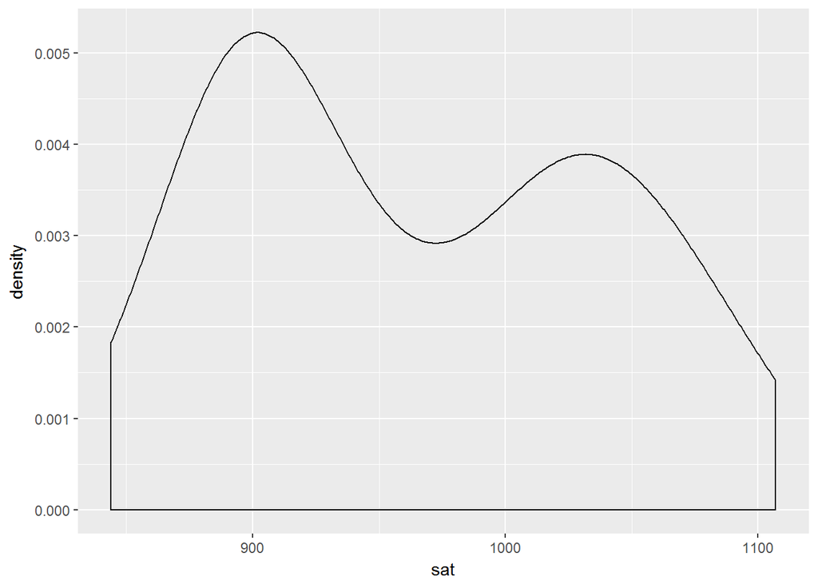

```r
ggplot(SAT, aes(x = sat)) +
  geom_density(kernel = "gaussian")
```

Where ggplot becomes powerful is the ability to quickly compare different categories.

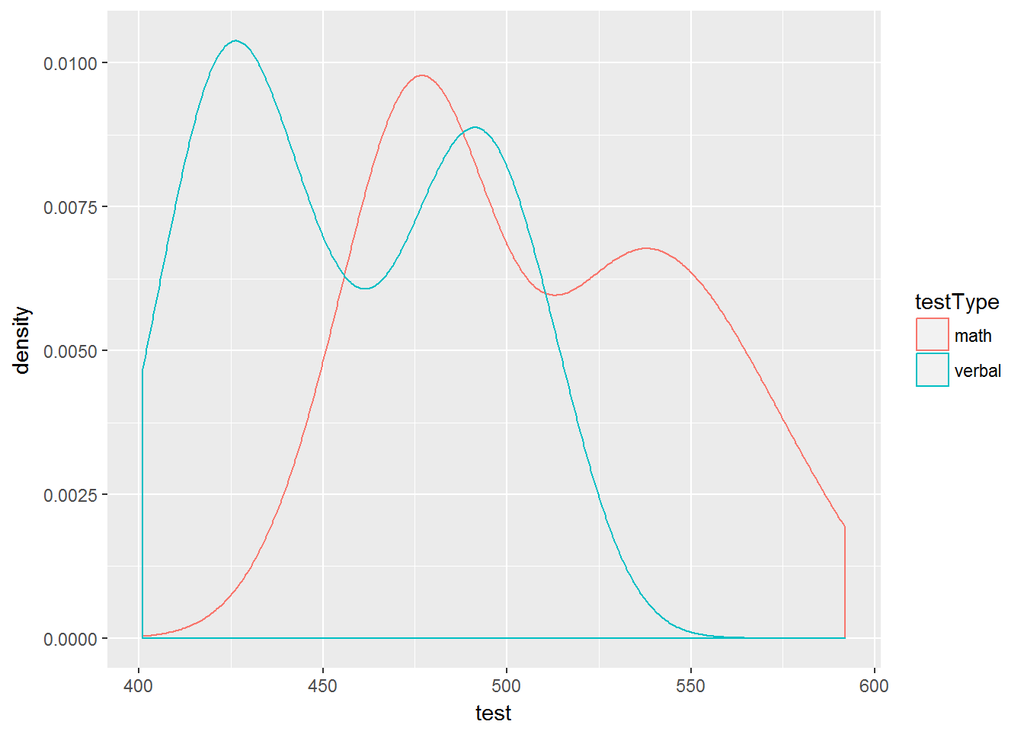

```r
SAT %>%
  gather(key = testType, value = test, verbal, math) %>%
  ggplot(aes(x = test, color = testType)) +
    geom_density(kernel = "gaussian")
```

A couple more aesthetics that we can manipulate include `fill` and `alpha`, where `alpha` is a proportion of how much color to use.

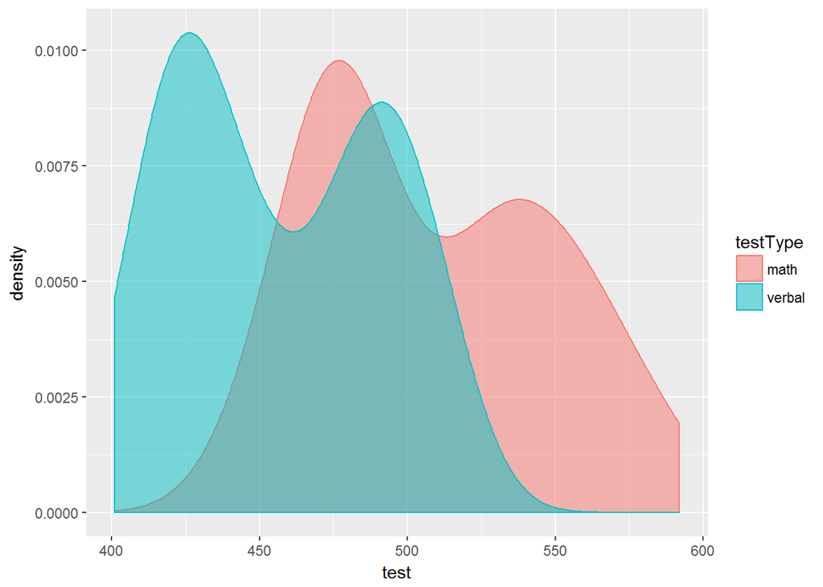

```r
SAT %>%
  gather(key = testType, value = test, verbal, math) %>%
  ggplot(aes(x = test, color = testType, fill = testType)) +
    geom_density(kernel = "gaussian", alpha = 0.5)
```

## Two, continuous variables

With two continuous variables, we can create a conventional scatterplot with `geom_point()`.

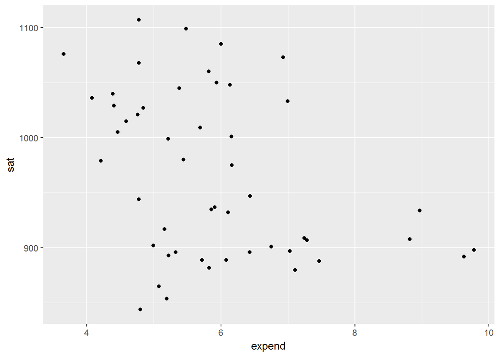

```r
ggplot(SAT, aes(x = expend, y = sat)) +
  geom_point()
```

Here we can label the points with another variable.

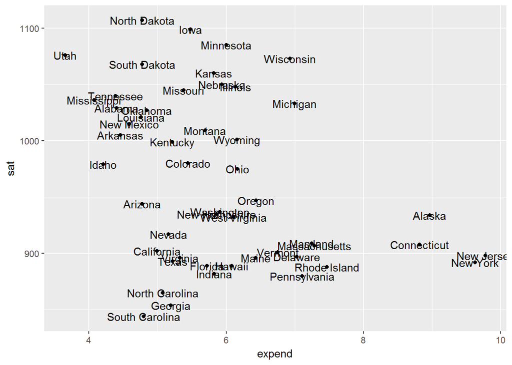

```r
ggplot(SAT, aes(x = expend, y = sat)) +
  geom_point() +
  geom_text(aes(label = state))
```

We can manipulate the placement of the text.

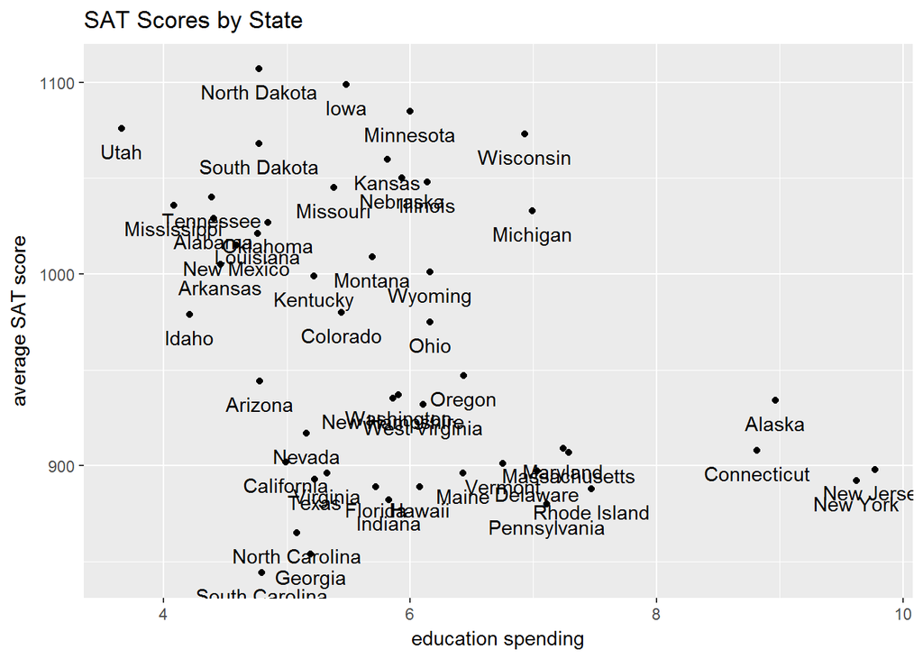

```r
ggplot(SAT, aes(x = expend, y = sat)) +
  geom_point() +
  geom_text(aes(label = state), vjust = 2) +
  ggtitle("SAT Scores by State") +
  xlab("education spending") +
  ylab("average SAT score")
```

## Facet Grids

Sometimes we want side-by-side graphs.

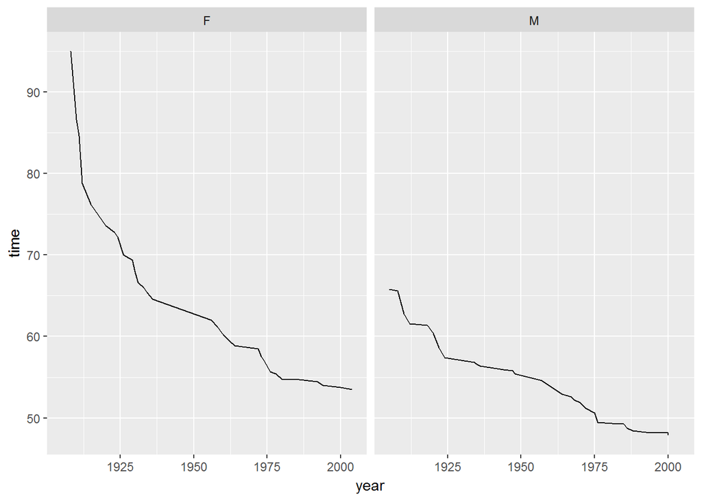

```r
data("SwimRecords")
ggplot(SwimRecords, aes(x = year, y = time)) +
  geom_line() +
  facet_grid(. ~ sex)
```

## Color Brewer

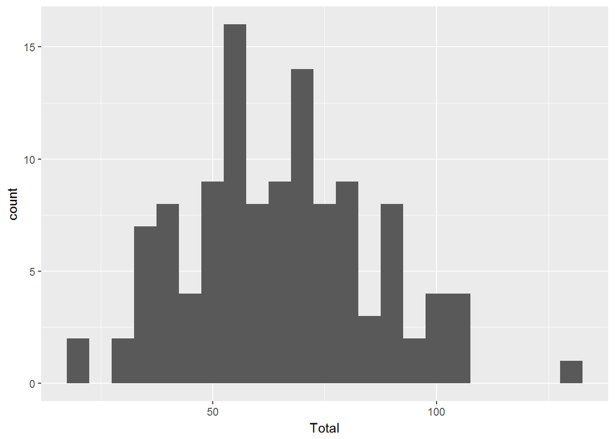

```r
data("SnowGR")
ggplot(SnowGR, aes(x = Total)) +
  geom_histogram(binwidth = 5)
```

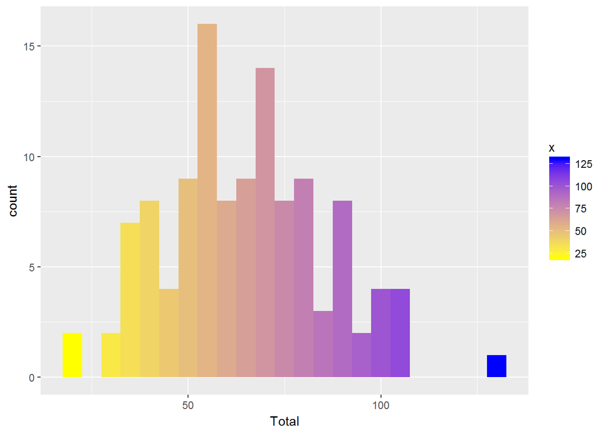

```r
ggplot(SnowGR, aes(x = Total, fill = ..x..)) +
  geom_histogram(binwidth = 5) +
  scale_fill_gradient(low = "yellow", high = "blue")
```

## Example: Opiate Addiction

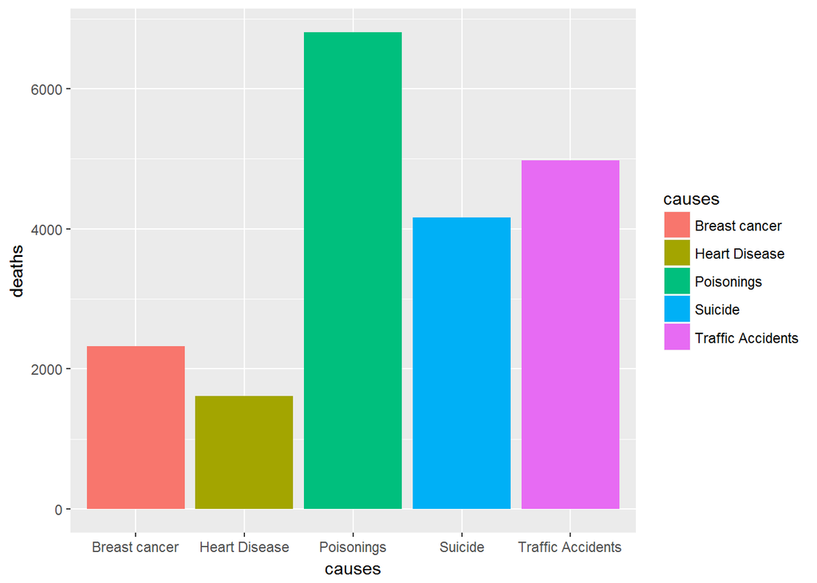

```r
causes <- c("Poisonings", "Traffic Accidents", "Suicide", "Breast cancer", "Heart Disease")
deaths <- c(6803, 4979, 4159, 2325, 1612)
df <- data.frame(causes, deaths)
ggplot(df, aes(x = causes, y = deaths)) +
  geom_bar(aes(fill = causes), stat = "identity")
```